# Lab 03: Pitch Classification

Author

Afnan Dzaharudin

Published

February 12, 2024

## Introduction

In the renowned sport of baseball, the [pitcher](https://en.wikipedia.org/wiki/Pitcher) is entrusted with the task of getting a batter ruled out. To this end, pitchers employ a wide range of pitches of various speeds, spin-rates, angles, and more general harnessings of physics, to ultimately get a ball past the batter.

Baseball fans are interested in knowing the type of pitches that pitchers pitch[^1]! This is not necessarily easily done by sight; camera angles aren’t necessarily conducive to recognizing the curvature of the pitch (and if a pitch is meant to confuse a batter, it’ll probably confuse you too).

So, can we use machine learning in our stead? Let’s try it!

## Methods

```python
# imports
import pandas as pd
import numpy as np
import matplotlib.pyplot as plt
import seaborn as sns
sns.set_theme(style="ticks", palette="deep")

from sklearn.pipeline import Pipeline
from sklearn.impute import SimpleImputer
from sklearn.preprocessing import StandardScaler, OneHotEncoder
from sklearn.compose import ColumnTransformer
from sklearn.tree import DecisionTreeClassifier
from sklearn.model_selection import GridSearchCV

# show me ALL the plots!
from IPython.display import display

# For fun!
from timeit import default_timer as timer

from joblib import dump
```

In this report, we first take a look at some summary statistics and visualizations about how our features trend for each type of pitch, to get a feel for what we should consider when fitting our model. We then use a Decision Tree classifier to fit our features, trying several impurity criteria, depth maxima, minimum samples for splitting, and imputation strategies to achieve as high as possible of a classification accuracy.

### Data

```python
# load data
pitches_train = pd.read_csv("https://cs307.org/lab-03/data/pitches-train.csv")
pitches_train
```

Table 1: First and Last Five Rows of the `pitches_train` Dataset

|  | pitch_name | release_speed | release_spin_rate | pfx_x | pfx_z | stand |
| --- | --- | --- | --- | --- | --- | --- |
| 0 | Sweeper | 84.7 | 2667.0 | 1.25 | 0.01 | R |
| 1 | Sweeper | 83.9 | 2634.0 | 1.41 | 0.20 | R |
| 2 | Sweeper | 84.4 | 2526.0 | 1.26 | 0.25 | R |
| 3 | Curveball | 74.3 | 2389.0 | 0.93 | -1.10 | L |
| 4 | Sweeper | 85.6 | 2474.0 | 1.08 | 0.52 | R |
| ... | ... | ... | ... | ... | ... | ... |
| 2623 | Split-Finger | 91.8 | 1314.0 | -0.30 | 0.08 | R |
| 2624 | Sweeper | 86.9 | 2440.0 | 1.11 | 0.51 | R |
| 2625 | 4-Seam Fastball | 99.2 | 2320.0 | 0.04 | 0.81 | R |
| 2626 | 4-Seam Fastball | 97.9 | 2164.0 | 0.08 | 1.06 | R |
| 2627 | 4-Seam Fastball | 99.8 | 2182.0 | -0.19 | 1.07 | R |

2628 rows × 6 columns

Our data will be all the pitches from one pitcher, Shohei Ohtani, in 2022. This still gives us a plentiful 2628 rows to utilize, which is sufficient for modeling.

Table 2: Descriptions for Each Variable

[output not shown]

#### Summary Statistics

```python
s_count = pitches_train["pitch_name"].value_counts()
s_prop = pitches_train["pitch_name"].value_counts(normalize=True)

tbl_count = pd.DataFrame({'count' : s_count, 'prop': s_prop}).sort_index()

tbl_velocity = pitches_train[["pitch_name", "release_speed"]] \
    .groupby("pitch_name") \
    .agg(["mean", "std"])

tbl_spin = pitches_train[["pitch_name", "release_spin_rate"]] \
    .groupby("pitch_name") \
    .agg(["mean", "std"])

display(tbl_count)

display(tbl_velocity)
display(tbl_spin)
```

Table 3: Shohei Otani’s Pitch Statistics

(a) Count and Proportion of Each Pitch Type Performed

| pitch_name | count | prop |
| --- | --- | --- |
| 4-Seam Fastball | 718 | 0.273212 |
| Curveball | 222 | 0.084475 |
| Cutter | 233 | 0.088661 |
| Sinker | 97 | 0.036910 |
| Slider | 63 | 0.023973 |
| Split-Finger | 312 | 0.118721 |
| Sweeper | 983 | 0.374049 |

(b) Release Speed (mph) by Pitch Name

| pitch_name | release_speed mean | release_speed std |
| --- | --- | --- |
| 4-Seam Fastball | 97.270613 | 1.699270 |
| Curveball | 77.679730 | 3.215206 |
| Cutter | 90.742060 | 2.364489 |
| Sinker | 97.160825 | 1.829592 |
| Slider | 85.203175 | 2.401543 |
| Split-Finger | 89.291346 | 1.759299 |
| Sweeper | 85.336419 | 1.862552 |

(c) Release Spin Rate (rpm) by Pitch Name

| pitch_name | release_spin_rate mean | release_spin_rate std |
| --- | --- | --- |
| 4-Seam Fastball | 2217.331933 | 114.754683 |
| Curveball | 2482.666667 | 119.854726 |
| Cutter | 2378.424893 | 206.685887 |
| Sinker | 1972.747368 | 143.920632 |
| Slider | 2497.619048 | 78.679306 |
| Split-Finger | 1273.560897 | 221.291146 |
| Sweeper | 2492.172940 | 103.176892 |

#### Visualizations

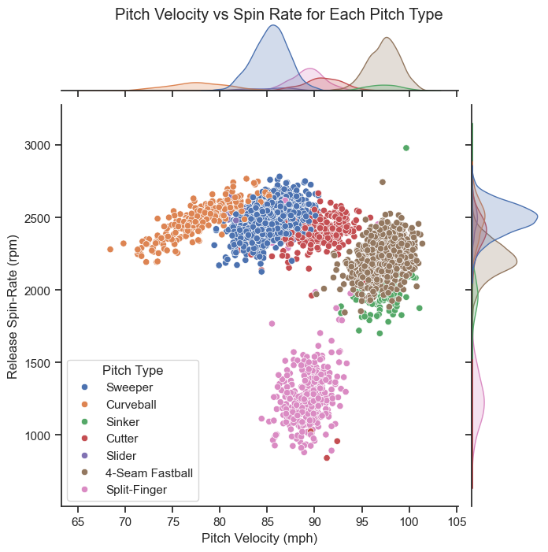

Figure 1: Joint-plot of Pitch Velocity and Spin Rate by Pitch Type

```python
sns.jointplot(pitches_train, x = "release_speed", y = "release_spin_rate",
              hue = "pitch_name", height=7)

plt.suptitle("Pitch Velocity vs Spin Rate for Each Pitch Type",
             y = 1.0) # Title intersects with the histogram a little
plt.xlabel("Pitch Velocity (mph)")
plt.ylabel("Release Spin-Rate (rpm)")
plt.legend(title="Pitch Type")

plt.show()
```

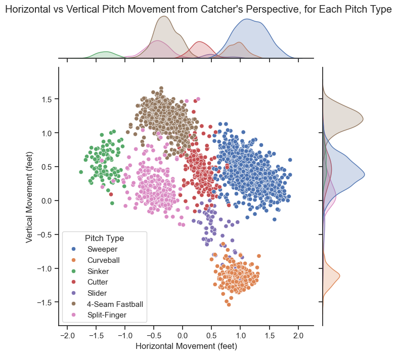

Figure 2: Joint-plot of Horizontal and Vertical Pitch Movement by Pitch Type

```python
sns.jointplot(pitches_train, x = "pfx_x", y = "pfx_z",
              hue = "pitch_name", height=7)
plt.suptitle("Horizontal vs Vertical Pitch Movement from Catcher's Perspective, for Each Pitch Type",
             y = 1.0)

plt.xlabel("Horizontal Movement (feet)")
plt.ylabel("Vertical Movement (feet)")
plt.legend(title="Pitch Type")

plt.show()
```

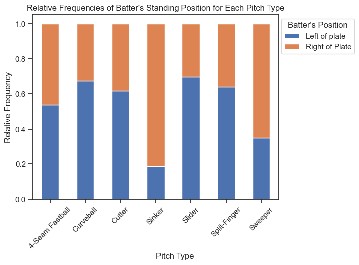

Figure 3: Barplot of Batter’s Standing Position by Pitch Type

```python
pd.crosstab(pitches_train["pitch_name"], pitches_train["stand"],
            normalize='index').plot.bar(stacked=True)
plt.title("Relative Frequencies of Batter's Standing Position for Each Pitch Type")
plt.xlabel("Pitch Type", ha='left')
plt.xticks(rotation=45, position=(-5, 0))
plt.ylabel("Relative Frequency")
plt.legend(title="Batter's Position",
           labels=["Left of plate", "Right of Plate"],
           loc="upper right", bbox_to_anchor = (1.32, 1.0))

plt.show()
```

It’s a lot of tables and especially plots! Let’s break them down.

I prefer talking over visualizations than tables, so we’ll just gloss over what stands out in the tables. From Table 3 (a), we can get an idea of what Ohtani’s preferred pitches are. 37.4% of his pitches are *sweepers* and another 27% of them are *4-seam fastballs*. His least-used pitch is the *slider*, at 2.4%. We should be weary when talking about the less-common pitches, as we may just not have enough data on them as the other pitches.

Moving on to the plots! Looking at velocity versus spin rate in Figure 1, it seems that Ohtani’s *split-fingers* are a well-seperated pitch type from the pack (even then, there’s some *cutters* in that cluster). There’s a lot of overlap between *curveballs*, *sweepers*, and most *cutters*, and there’s another overlapping cluster of mostly *4-seam fastballs* and some *sinkers*. Using these features as a Decision Tree parameter might be good for classifying *split-fingers*, but there is otherwise a significant amount of impurity from this pair of features.

Figure 2 is promising. Plotting between the pitch’s vertical movemetn and horizontal movement (catcher’s perspective), the pitch types are generally much more well-separated. There’s still a fair bit of area where the pitches blend in, but these could be helpful features for our Decision Tree.

Now that we understand how our data look like with respect to `pitch_type`, we can begin to fit our model.

### Models

```python
# process data for ML
y_train = pitches_train["pitch_name"]
X_train = pitches_train.drop("pitch_name", axis=1)

numeric_cols = X_train.select_dtypes("number").columns
categorical_cols = X_train.select_dtypes("object").columns

numeric_transformer = Pipeline(
    [
        ("Numeric Imputer", SimpleImputer()),
        ("Standard Scaler", StandardScaler())
    ]
)

categorical_transformer = Pipeline(
    [
        ("Categorical Imputer", SimpleImputer(strategy="most_frequent")),
        ("One-Hot Encoder", OneHotEncoder(handle_unknown="ignore"))
    ]
)

preprocessor = ColumnTransformer(
    [
        ("Numeric Transformer", numeric_transformer, numeric_cols),
        ("Categorical Transformer", categorical_transformer, categorical_cols)
    ]
)

pipeline = Pipeline([
    ("Preprocessor", preprocessor),
    ("Classifier", DecisionTreeClassifier())
])

param_grid = {
    "Preprocessor__Numeric Transformer__Numeric Imputer__strategy": ["mean", "median"], # For fun
    "Classifier__criterion": ["gini", "entropy"],
    "Classifier__splitter": ["best"],
    "Classifier__random_state": [42], # Get that randomness out of here
    "Classifier__max_depth": [None, 5, 10, 15, 20, 25],
    "Classifier__min_samples_split": np.arange(2, 20, 2)
}

grid_search = GridSearchCV(pipeline, param_grid, cv=5, scoring="accuracy")
```

```python
# train models

start = timer()
grid_search.fit(X_train, y_train)
end = timer()

display(grid_search)
print("Ran in {} seconds".format(end - start))
```

```
GridSearchCV(cv=5,
             estimator=Pipeline(steps=[('Preprocessor',
                                        ColumnTransformer(transformers=[('Numeric '
                                                                         'Transformer',
                                                                         Pipeline(steps=[('Numeric '
                                                                                          'Imputer',
                                                                                          SimpleImputer()),
                                                                                         ('Standard '
                                                                                          'Scaler',
                                                                                          StandardScaler())]),
                                                                         Index(['release_speed', 'release_spin_rate', 'pfx_x', 'pfx_z'], dtype='object')),
                                                                        ('Categorical '
                                                                         'Transformer',
                                                                         Pipeline(steps=[('Categorical '
                                                                                          'Imput...
                                        DecisionTreeClassifier())]),
             param_grid={'Classifier__criterion': ['gini', 'entropy'],
                         'Classifier__max_depth': [None, 5, 10, 15, 20, 25],
                         'Classifier__min_samples_split': array([ 2,  4,  6,  8, 10, 12, 14, 16, 18]),
                         'Classifier__random_state': [42],
                         'Classifier__splitter': ['best'],
                         'Preprocessor__Numeric Transformer__Numeric Imputer__strategy': ['mean',
                                                                                          'median']},
             scoring='accuracy')
```

Figure 4: Scikit-Learn Pipeline Summary

```
Ran in 19.521265551000397 seconds
```

## Results

```python
# report model
pd.Series(grid_search.best_params_)
```

```
Classifier__criterion                                           entropy
Classifier__max_depth                                              None
Classifier__min_samples_split                                        18
Classifier__random_state                                             42
Classifier__splitter                                               best
Preprocessor__Numeric Transformer__Numeric Imputer__strategy     median
dtype: object
```

Figure 5: Best Parameters Found

```python
df_metrics = pd.DataFrame(grid_search.cv_results_)[["param_Classifier__criterion", "param_Classifier__max_depth", "param_Classifier__min_samples_split", "param_Preprocessor__Numeric Transformer__Numeric Imputer__strategy", "mean_test_score"]]
df_metrics.columns = ["Criterion", "Max depth", "Min. Samples Split", "Numeric Imputer", "Accuracy"]

df_metrics.sort_values("Accuracy", ascending=False).head(15)
```

Table 4: Top 15 Accuracies Obtained from Various Decision Tree Hyperparameters

|  | Criterion | Max depth | Min. Samples Split | Numeric Imputer | Accuracy |
| --- | --- | --- | --- | --- | --- |
| 215 | entropy | 25 | 18 | median | 0.961563 |
| 179 | entropy | 15 | 18 | median | 0.961563 |
| 197 | entropy | 20 | 18 | median | 0.961563 |
| 161 | entropy | 10 | 18 | median | 0.961563 |
| 125 | entropy | None | 18 | median | 0.961563 |
| 195 | entropy | 20 | 16 | median | 0.961562 |
| 123 | entropy | None | 16 | median | 0.961562 |
| 177 | entropy | 15 | 16 | median | 0.961562 |
| 213 | entropy | 25 | 16 | median | 0.961562 |
| 159 | entropy | 10 | 16 | median | 0.961562 |
| 84 | gini | 20 | 14 | mean | 0.960799 |
| 85 | gini | 20 | 14 | median | 0.960799 |
| 102 | gini | 25 | 14 | mean | 0.960799 |
| 12 | gini | None | 14 | mean | 0.960799 |
| 13 | gini | None | 14 | median | 0.960799 |

The `GridSearchCV` object declares the best parameters to use `"entropy"`, `None` or unbounded node depth, splitting nodes at a minimum of `18` samples, and replacing `NaN` values through `"median"` imputation.

## Discussion

Despite the apparent “best params,” we disagree with the model chosen by the grid-search.

We would not want an overly-flexible model that fits to the training set’s “noise” alongside its true pattern, which is why we argue that choosing a decision tree with limited node depth would be more ideal than leaving it unbounded. It’s hard to tell which node depth is ideal though; they all get roughly the same results.

So, can our model accurately classify a pitcher’s pitches? Sort of! To be clear, the model’s very good at classifying *Shohei Ohtani’s pitches, in 2022*.

- **This does not guarantee us that it will be a good model for classifying other pitchers’ pitches.** Different pichers have different strengths – possibly literally, in terms of physical ability. Pitchers could generally throw faster or slower pitches on average, or pitches with more or less spin. They may also have different preferences – Ohtani rarely does sinkers or sliders, but this may be less the case for other pitchers. This is nothing to say of **new pitchers**, who may introduce a totally new mixup, or even **new pitches**!
- **It also doesn’t guarantee we’ll even accurately predict Ohtani’s *future* pitches.** Ohtani may pitch sinkers more often in the future than 4-seam fastballs or sweepers. During the off-season, he may even come up with different ways to pitch his usuals at different speeds. Good pitchers probably don’t do use one same trick for too long. Unless the model gets to keep up-to-date with Ohtani’s most recent pitches, it’ll fall behind eventually.

One last thing: could our model be used to classify a pitch in real-time, like the machine learning models used on television at MLB?

```python
start = timer()
grid_search.predict(X_train)
end = timer()

print("Predicting on {} rows took {} seconds".format(X_train.shape[0], end - start))
print("Predicting on 1 row would take ~{} seconds".format((end - start)/ X_train.shape[0]))
```

```
Predicting on 2628 rows took 0.0053014000004623085 seconds
Predicting on 1 row would take ~2.0172754948486715e-06 seconds
```

Yes! It takes a fraction of a second for the model to predict on just one row of inputs, which is what would happen, since there’s only one pitch happening at a time. The bottleneck would not be the prediction model, but how fast the tracking technology can measure the pitch metrics.

### Conclusion

If a decision tree were chosen to predict MLB pitches, we would choose one that uses entropy to calculate impurity, splits nodes at a minimum of 16 to 18 samples, and is limited to a maximum depth of 25 or less. This procures an accuracy of about 96%; predicting 96 out of 100 pitches. [If the average MLB game sees 300 pitches](https://baseballscouter.com/how-many-pitches-are-thrown-in-a-baseball-game/), then we can expect around 12 mispredictions. This is up to an actual baseball fan to decide whether that’s good or not!

That being said, for a significantly better model, consider updating or refitting the model every season with the newest data, and maybe even create one model for each pitcher, for best results.

## Footnotes

[^1]: I strongly assume this is the case, otherwise we wouldn’t be doing a lab on this, and otherwise there wouldn’t be machine learning models employed to classify these pitches on the fly in MLB.

    I’m sorry! I don’t baseball!